# Assignment 1: proposition of answers

## Warm-up

### Make sure you’ve installed {dplyr} >= 0.7 and {prenoms} package

### Load here `{dplyr}`, `{prenoms}` and any other needed package

```r
library(dplyr)
library(tidyr)
library(prenoms)
library(readr)
library(readxl)
library(ggplot2)
library(sf)
```

### Import

#### prenomsdataset

Using `data(prenoms)` load `prenoms` dataset from `{prenoms}` package.

```r
data(prenoms)
```

What kind of object is `prenoms` ?

```r
class(prenoms)
```

```
## [1] "tbl_df"     "tbl"        "data.frame"
```

Explore the database using the ‘5-functions-to-always-run-on-a-database’

```r
dim(prenoms)
names(prenoms)
head(prenoms)
View(prenoms)
summary(prenoms)
```

Using `glimpse`, have a look at `prenoms`’s structure.

```r
glimpse(prenoms)
```

```
## Observations: 3,712,763
## Variables: 6
## $ year <int> 1900, 1900, 1900, 1900, 1900, 1900, 1900, 1900, 1900, 190...
## $ sex  <chr> "F", "F", "F", "F", "F", "F", "F", "F", "F", "F", "F", "F...
## $ name <chr> "Adèle", "Adrienne", "Aimée", "Alice", "Alphonsine", "Amé...
## $ n    <int> 5, 9, 7, 24, 5, 8, 5, 6, 21, 12, 21, 6, 5, 5, 17, 3, 5, 1...
## $ dpt  <chr> "01", "01", "01", "01", "01", "01", "01", "01", "01", "01...
## $ prop <dbl> 0.0015777848, 0.0028400126, 0.0022088987, 0.0075733670, 0...
```

#### Regions, departements and surfaces

Load the “dpt_data_modif.csv” dataset from IGN (French public state administrative establishment founded in 1940[1] to produce and maintain geographical information for France and its overseas departments and territories) using the appropriate function. Data have been prepared for you: the surface of departement has been calculated and spatial data removed.

```r
dpt_data_modif <- read_csv("data/dpt_data_modif.csv")
```

#### Elementary and college schools

We also fetched for you on [data.gouv.fr](https://www.data.gouv.fr/fr/datasets/adresse-et-geolocalisation-des-etablissements-denseignement-du-premier-et-second-degres/#_) the addresses of “primary and secondary schools, the administrative structures of the Ministry of National Education. Public and private sectors.”

1. Data preprocessing
   - Import the csv file : “DEPP-etab-1D2D.csv” and name it “depp_orig”
     - Encoding is `"latin1"`
   - Transform zip code (“code_postal_uai”) into 5 characters with zeros
   - Extract department numbers (“dpt”) starting from column “code_postal_uai”
   - Save the modifications into “depp_modif.csv”

```r
depp_orig <- read.csv2("data/DEPP-etab-1D2D.csv",
                       encoding = "latin1")

depp_modif <- depp_orig %>%
  mutate(code_postal_uai =
           formatC(code_postal_uai, width = 5, flag = "0")) %>%
  mutate(dpt = substr(code_postal_uai, 1,2))

write_csv(depp_modif, "data/depp_modif.csv")
```

2. Read the pre-processed “depp_modif.csv” file

```r
depp_modif <- read_csv("data/depp_modif.csv")
```

#### Facts observed by the police services and national gendarmerie units by department

We also gathered data from [data.gouv.fr](https://www.data.gouv.fr/fr/datasets/faits-constates-par-index-par-departement-et-par-annee/#_) concerning “all the facts observed by the police services and national gendarmerie units by department from 1996 to 2011”

1. Data preprocessing
   - Import Excel sheet “2010” from “faitsconstatespardepartementde2002-a-2011.xls” file
     - *beware of the original formatting*
   - Copy it into “faits_2010_modif” in order to make some modifications:
     - Delete Excel calculations:
       - `Tout_département`, `Tout_index`
     - Transform in long format using `gather`
       - 4 columns : Index, Libellé, dpt, nombre
     - save the dataframe into a csv file “faits_2010_modif.csv”

```r
faits_2010_orig <- read_excel(
  "data/faitsconstatespardepartementde2002-a-2011.xls",
  sheet = "2010", skip = 2
)

# Supprimer les données issues de calculs dans Excel
faits_2010_modif <- faits_2010_orig[-1,-3] %>%
  gather(dpt, nombre, -Index, -Libellé)

write_csv(faits_2010_modif, "data/faits_2010_modif.csv")
```

2. Read preprocessed file “faits_2010_modif.csv”

```r
faits_2010_modif <- read_csv("data/faits_2010_modif.csv")
```

## Analyses

Some assumptions to do the exercise:

- every child born in a department stays into that department until the end of college
- every children between 11 and 14 years old is in a college
- the number of college is constant between 2010 and 2016
- College “à ouvrir” (i.e. “to be open”) do not have children. Others have.

### Filter datasets to Metropolitan France

Datasets to be filtered: `prenoms`, `depp_modif`, `faits_2010_modif`, `dpt_data_modif`

- Department named “2A” and “2B” should be merged to “20”
- We only work with data in Metropolitan France, which means for “dpt” between `01` and `95` included. Others needs to be filtered.

```r
prenoms_metro <- prenoms %>%
  mutate(dpt = if_else(dpt %in% c("2A", "2B"), "20", dpt)) %>%
  filter(dpt %in% formatC(1:95, width = 2, flag = "0"))

depp_metro <- depp_modif %>%
  mutate(dpt = if_else(dpt %in% c("2A", "2B"), "20", dpt)) %>%
  filter(dpt %in% formatC(1:95, width = 2, flag = "0"))

faits_2010_metro <- faits_2010_modif %>%
  mutate(dpt = if_else(dpt %in% c("2A", "2B"), "20", dpt)) %>%
  filter(dpt %in% formatC(1:95, width = 2, flag = "0"))

dpt_data_metro <- dpt_data_modif %>%
    mutate(CODE_DEPT = if_else(CODE_DEPT %in% c("2A", "2B"), "20", CODE_DEPT)) %>%
  filter(CODE_DEPT %in% formatC(1:95, width = 2, flag = "0"))

dpt_data_metro
```

```
## # A tibble: 96 x 7
##    CODE_DEPT NOM_DEPT   CODE_CHF NOM_CHF   CODE_REG NOM_REG      surface_m
##    <chr>     <chr>      <chr>    <chr>        <int> <chr>            <dbl>
##  1 39        JURA       300      LONS-LE-…       27 BOURGOGNE-F…    5.04e9
##  2 42        LOIRE      218      SAINT-ET…       84 AUVERGNE-RH…    4.80e9
##  3 76        SEINE-MAR… 540      ROUEN           28 NORMANDIE       6.33e9
##  4 89        YONNE      024      AUXERRE         27 BOURGOGNE-F…    7.45e9
##  5 68        HAUT-RHIN  066      COLMAR          44 ALSACE-CHAM…    3.53e9
##  6 28        EURE-ET-L… 085      CHARTRES        24 CENTRE-VAL …    5.93e9
##  7 10        AUBE       387      TROYES          44 ALSACE-CHAM…    6.02e9
##  8 55        MEUSE      029      BAR-LE-D…       44 ALSACE-CHAM…    6.23e9
##  9 61        ORNE       001      ALENCON         28 NORMANDIE       6.14e9
## 10 67        BAS-RHIN   482      STRASBOU…       44 ALSACE-CHAM…    4.80e9
## # ... with 86 more rows
```

### National average number of children per college in 2010 ?

```r
# Enfants ayant 11 à 14 ans en 2010
nb_enfants <- prenoms_metro %>%
  filter(year >= 1996 & year <= 1999) %>%
  summarise(total = sum(n))

# Nombre de collèges en France en 2010 (=2016)
nb_colleges <- depp_metro %>%
  filter(nature_uai_libe == "Collège" &
           etat_etablissement) %>%
  nrow()

# Nombre d'enfants par collège au niveau national en 2010
nb_enfants/nb_colleges
```

```
##      total
## 1 348.8871
```

### Average number of children per college in 2010 in each department?

- Arrange departments according to the calculated average in descending order

```r
# Enfants ayant 11 à 14 ans en 2016 par dpt
nb_enfants <- prenoms_metro %>%
  filter(year >= 1996 & year <= 1999) %>%
  group_by(dpt) %>%
  summarise(enf = sum(n))

# Nombre de collèges en France en 2016
nb_colleges <- depp_metro %>%
  filter(nature_uai_libe == "Collège") %>%
  group_by(dpt) %>%
  summarise(coll = n())

# Jointure
enf_coll <- inner_join(nb_enfants, nb_colleges, by = "dpt") %>%
  mutate(ratio = enf/coll) %>%
  arrange(desc(ratio))

enf_coll
```

```
## # A tibble: 95 x 4
##    dpt      enf  coll ratio
##    <chr>  <int> <int> <dbl>
##  1 75    138387   190  728.
##  2 92     84505   139  608.
##  3 69     87948   169  520.
##  4 59    138285   288  480.
##  5 76     59816   133  450.
##  6 84     24903    58  429.
##  7 42     32065    77  416.
##  8 51     25268    61  414.
##  9 74     29315    71  413.
## 10 68     29188    71  411.
## # ... with 85 more rows
```

### Number of Facts observed by the police services in 2010 per department ?

```r
# Nb faits par dpt en 2010
faits_2010_metro %>%
  group_by(dpt) %>%
  summarise(faits = sum(nombre))
```

```
## # A tibble: 95 x 2
##    dpt   faits
##    <chr> <int>
##  1 01    22615
##  2 02    24052
##  3 03    11653
##  4 04     7035
##  5 05     5303
##  6 06    93308
##  7 07    11011
##  8 08    10795
##  9 09     4829
## 10 10    14360
## # ... with 85 more rows
```

### Number of children born, number of colleges and facts related by the police services per department in 2010 ?

- Group all information in the same table
- Arrange by descending order of children, schools and facts

```r
# Enfants nés en 2010 par dpt
nb_enfants <- prenoms_metro %>%
  filter(year == 2010) %>%
  group_by(dpt) %>%
  summarise(nb_enfants = sum(n))

# Nombre de collèges en France en 2016
nb_colleges <- depp_metro %>%
  filter(nature_uai_libe == "Collège") %>%
  group_by(dpt) %>%
  summarise(nb_colleges = n())

# Nb faits par dpt en 2010
nb_faits <- faits_2010_metro %>%
  group_by(dpt) %>%
  summarise(nb_faits = sum(nombre))

# Jointure par dpt
all_by_dpt <- nb_enfants %>%
  inner_join(nb_colleges, by = "dpt") %>%
  inner_join(nb_faits, by = "dpt") %>%
  arrange(desc(nb_enfants), desc(nb_colleges), desc(nb_faits))

all_by_dpt
```

```
## # A tibble: 95 x 4
##    dpt   nb_enfants nb_colleges nb_faits
##    <chr>      <int>       <int>    <int>
##  1 75         35795         190   238856
##  2 59         33771         288   166565
##  3 69         23073         169   115632
##  4 92         22114         139    96520
##  5 13         21893         194   172445
##  6 93         16082         158   142798
##  7 62         14983         160    73918
##  8 76         14878         133    66765
##  9 44         14539         147    71222
## 10 94         14355         138    90376
## # ... with 85 more rows
```

### Number of children born, number of colleges and facts related by the police services per km² in 2010 by department?

```r
stats_km2 <- dpt_data_modif %>%
  mutate(surface_km = surface_m / 1e6) %>%
  inner_join(all_by_dpt, by = c("CODE_DEPT" = "dpt")) %>%
  mutate_if(is.integer, as.numeric) %>% # facultatif
  mutate_at(vars(starts_with("nb_")), funs(bykm = ./surface_km))

stats_km2 %>%
  select("CODE_DEPT", "NOM_DEPT", ends_with("bykm"), everything())
```

```
## # A tibble: 94 x 14
##    CODE_DEPT NOM_DEPT nb_enfants_bykm nb_colleges_bykm nb_faits_bykm
##    <chr>     <chr>              <dbl>            <dbl>         <dbl>
##  1 39        JURA               0.302          0.00734          1.65
##  2 42        LOIRE              1.63           0.0161           7.24
##  3 76        SEINE-M…           2.35           0.0210          10.6
##  4 89        YONNE              0.287          0.00470          2.14
##  5 68        HAUT-RH…           1.87           0.0201           9.14
##  6 28        EURE-ET…           0.562          0.00844          2.97
##  7 10        AUBE               0.362          0.00565          2.38
##  8 55        MEUSE              0.148          0.00465          1.09
##  9 61        ORNE               0.353          0.00733          1.64
## 10 67        BAS-RHIN           2.18           0.0231          10.3
## # ... with 84 more rows, and 9 more variables: CODE_CHF <chr>,
## #   NOM_CHF <chr>, CODE_REG <dbl>, NOM_REG <chr>, surface_m <dbl>,
## #   surface_km <dbl>, nb_enfants <dbl>, nb_colleges <dbl>, nb_faits <dbl>
```

### Is there a correlation between the number of birth and the number of facts related by the police per km² in 2010 ?

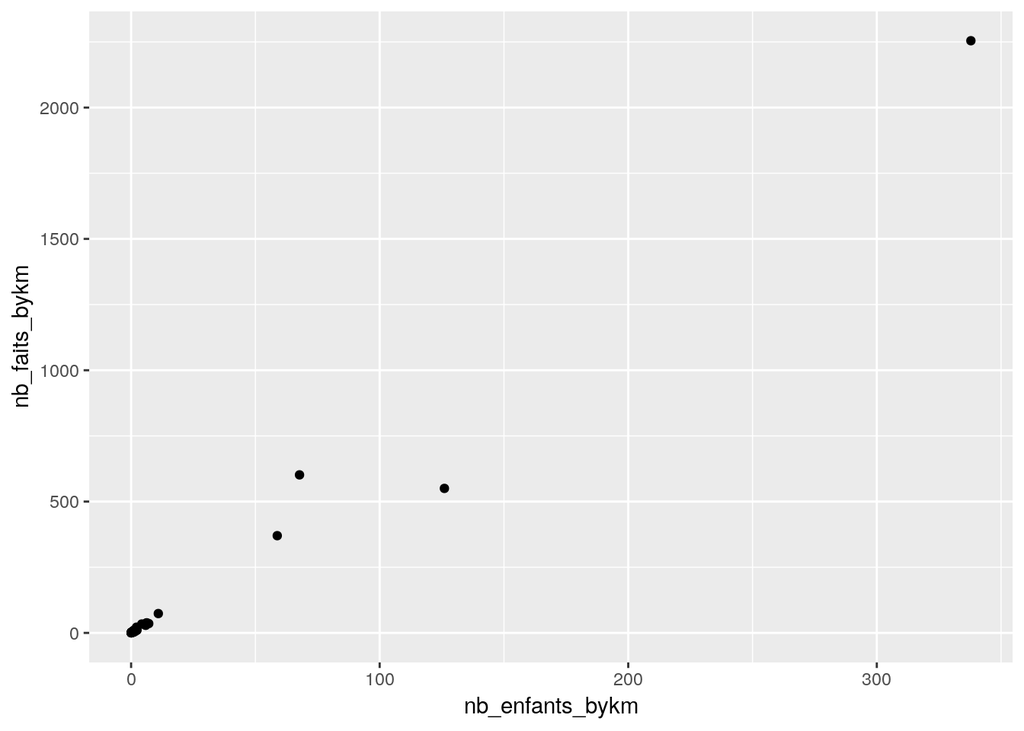

```r
ggplot(stats_km2) +
  geom_point(aes(nb_enfants_bykm, nb_faits_bykm))
```

```r
cor(stats_km2$nb_enfants_bykm, stats_km2$nb_faits_bykm, use = "pairwise.complete.obs")
```

```
## [1] 0.9909755
```

*Is this correlation value really interesting ? Think about the distribution of the data…*

### What is the regional density (in number/km²) of the 15 most given first names in France ?

- Filter the 15 most given first names in France
- Create a unique wide table with the department as observations and the 15 most given names in columns (as variables): the count is at the row-column intersection
- Merge with the surface department infos
- Compute the region surface and the density of names by region (e.g. number of people named “Bob”, “Anna”, … by km² of each region)
  - Region name is stored in variable `NOM_REG`. (There are multiple departments in each region)

```r
# Top 15
top_prenoms <- prenoms %>%
  group_by(name) %>%
  summarise(total = sum(n)) %>%
  arrange(desc(total), name) %>%
  top_n(total, n = 15)

# Filter on top 15 and spread
top_spread <- prenoms %>%
  filter(name %in% pull(top_prenoms, name)) %>%
  group_by(dpt, name) %>%
  summarize(total = sum(n)) %>%
  spread(name, total)

# Join with surface in km2
top_dpt <- dpt_data_modif %>%
  mutate(surface_km = surface_m / 1e6) %>%
  inner_join(top_spread, by = c("CODE_DEPT" = "dpt"))

# Calculate Regional surface and total number by name
top_region <- top_dpt %>%
  group_by(NOM_REG) %>%
  summarise_if(is.numeric, sum)

# Calculate density
top_region_density <- top_region %>%
  mutate_at(vars(pull(top_prenoms, name)),
            funs(./surface_km))

top_region_density
```

```
## # A tibble: 13 x 19
##    NOM_REG CODE_REG surface_m surface_km  Alain André Bernard Claude Daniel
##    <chr>      <int>     <dbl>      <dbl>  <dbl> <dbl>   <dbl>  <dbl>  <dbl>
##  1 ALSACE…      440   5.77e10     57699. 0.804  1.25   0.902  0.876  0.849
##  2 AQUITA…      900   8.51e10     85103. 0.570  0.893  0.561  0.505  0.380
##  3 AUVERG…     1008   7.08e10     70796. 0.752  1.10   0.721  0.550  0.607
##  4 BOURGO…      216   4.80e10     47982. 0.528  0.914  0.622  0.562  0.583
##  5 BRETAG…      212   2.74e10     27383. 1.08   1.43   0.817  0.669  0.739
##  6 CENTRE…      144   3.95e10     39471. 0.535  0.834  0.591  0.568  0.488
##  7 CORSE        188   8.76e 9      8757. 0.0978 0.169  0.0393 0.0617 0.0541
##  8 ILE-DE…       88   1.21e10     12065. 7.41   8.18   5.01   7.16   6.10
##  9 LANGUE…      988   7.34e10     73413. 0.512  0.803  0.426  0.450  0.287
## 10 NORD-P…      160   3.20e10     32008. 1.73   2.64   1.94   1.49   1.86
## 11 NORMAN…      140   3.01e10     30119. 1.04   1.56   1.15   1.21   1.14
## 12 PAYS D…      260   3.24e10     32363. 0.868  1.17   0.960  0.882  0.773
## 13 PROVEN…      558   3.17e10     31675. 0.906  0.916  0.504  0.672  0.516
## # ... with 10 more variables: Jacques <dbl>, Jean <dbl>, Jeanne <dbl>,
## #   Louis <dbl>, Marcel <dbl>, Marie <dbl>, Michel <dbl>, Philippe <dbl>,
## #   Pierre <dbl>, René <dbl>
```

#### Bonus question : map the mean regional density (in number/km²) of the 15 most given first names in France

- Use the “department” shapefile to cross information and map data
  - Region name is stored in variable `NOM_REG`. (There are multiple departments in each region)
  - One map for each name

```r
region <- st_read(dsn = 'data/departements',
                    layer = 'DEPARTEMENT',
                    quiet = TRUE) %>%
  group_by(NOM_REG) %>%
  summarise() %>%
  inner_join(top_region_density, by = "NOM_REG")
```

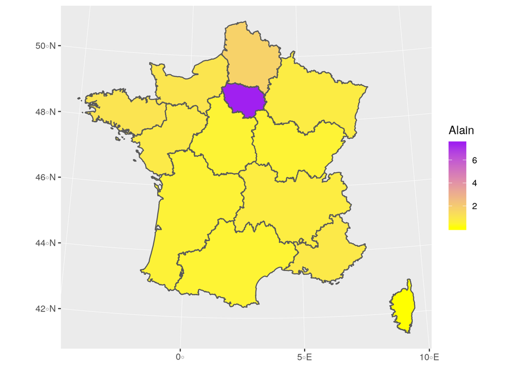

```r
# One map for one name
ggplot(region) +
  aes(fill = Alain) +
  geom_sf() +
  coord_sf(crs = 2154) +
  scale_fill_gradient(low = "yellow", high = "purple")
```

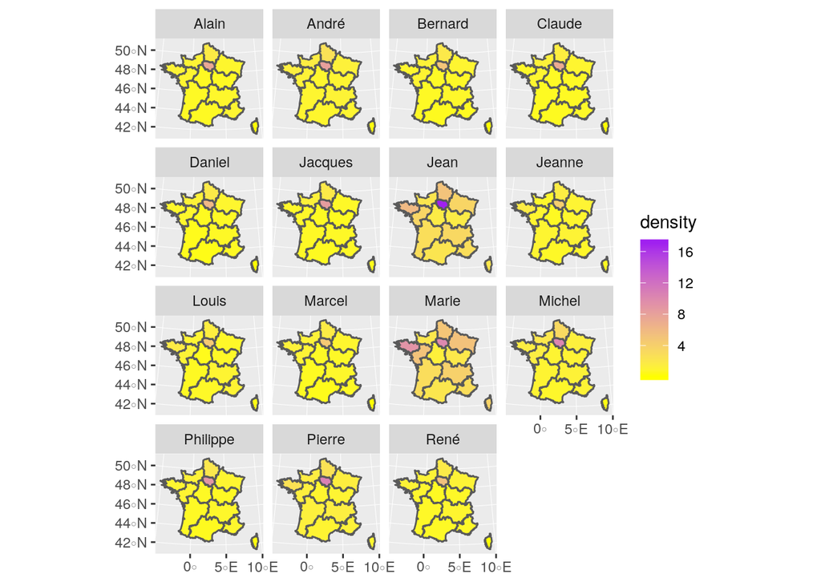

```r
# As facets for all names
region %>%
  gather(key = "name", value = "density", Alain:René) %>%
  ggplot() +
  aes(fill = density) +
  geom_sf() +
  coord_sf(crs = 2154) +
  scale_fill_gradient(low = "yellow", high = "purple") +
  facet_wrap(~name)
```